# A Study Guide for Quiz 1

Author

Jed Rembold

Published

February 14, 2025

The below materials are meant to provide you a sort of checklist of what you should ensure you are aware of going into the first quiz, as well as providing some example type questions. I’ve tried to specify by the word “Computing” in the outline what topics you should have the equations memorized for, and specify “Qualitatively” when you don’t need to know the specific equation, but just the general trends. The equations themselves are also included below, and there are not that many you should memorize.

# 1 Outline of Content

**Unit 1: The Solar System**

- The Celestial Sphere
  - Why do we talk about positions on the celestial sphere?
  - How is the celestial sphere oriented relative to Earth?
  - How do we record positions on the celestial sphere?
- Qualitative understanding of how angular separation relates to distance (shrinks as further away)
- What sorts of objects show movement in their positions on the celestial sphere?
- Equatorial coordinates
  - **Computing**: Converting arcminutes and arcseconds to degrees, and vice versa
  - Understanding why Right Ascension is often reported in hours, minutes, and seconds
  - **Computing**: Converting from hours:minutes:seconds formats to degrees, and vice versa
- Kepler’s Laws
  - First Law: **Computing**: work out position of central star from a given ellipse, or vice versa
  - Second Law: qualitative understanding only
  - Third Law: **Computing**: Simple expression, in terms of years, AU, and solar masses
- Ellipses
  - Vocabulary: major axis, semimajor axis, foci distance, eccentricity, aphelion, perihelion
- Gravity
  - Qualitative understanding: attractive, increases with mass, decreases with distance
- Magnitude
  - Qualitative understanding: bright objects equate to smaller numbers
- Asteroid Resonance: **Computing**: Are two orbits in resonance with one another (simple integer multiples in period)

**Unit 2: Light and Stars**

- Conceptual view of light as an electromagnetic wave
- Vocab: wavelength, amplitude, luminosity
- Approximate wavelengths of the endpoints of the visible color range
- Rough ordering of other radiation types by wavelength: E.g. X-rays are at much smaller wavelengths than Microwaves
- Qualitative understanding of Planck’s law
  - What happens to the spectral curve as the temperature increases?
- Absorption and Emission
  - Qualitatively, why to we get absorption and emission at specific wavelengths?
  - Identifying what type of spectra comes from different sources: absorption, emission, or black-body
- How does the Doppler effect change the spectra we see?
  - Identify from spectra whether an object is moving towards or away from the observer (no need for full calc)
- Qualitative relationship between luminosity, distance, and brightness
- **Computing**: what is a parallax angle, and how does it relate to distance in parsecs
- Qualitative understanding of what absolute magnitude is
- HR Diagrams
  - Identifying major groups on the diagram (MS, dwarfs, etc)
  - Identifying trends on the diagram:
    - Hotter vs colder stars
    - Brighter vs dimmer stars
    - Larger vs smaller stars
    - More massive vs less massive stars
    - Long living stars vs short living stars
  - General lifecycle of a star throughout the HR diagram
- Star Clusters
  - Why are star clusters interesting to astronomers?
  - Identifying star cluster age from an HR diagram

**Equations to Know**

$$\frac{1}{60}\text{ degree} = 1 \text{ arcminute} = 1'$$
$$\frac{1}{60}\text{ arcminute} = 1 \text{ arcsecond} = 1''$$
$$15\text{ degree} = 1\text{ hour}$$
$$\frac{a_{AU}^3}{p_{yr}^2} = \left(M_1 + M_2\right)_\odot$$
$$f = \sqrt{a^2 - b^2}$$
$$d_{pc} = \frac{1}{p_{asec}}$$

# 2 Example Problems

**Question 1**

Which of the following is most likely to have its right ascension and declination change slowly over time?

1. The bright star Betelgeuse
2. The Andromeda Galaxy
3. The open cluster Pleiades
4. The planet Venus

**Answer**

Which of the following is most likely to have its right ascension and declination change slowly over time?

1. The bright star Betelgeuse
2. The Andromeda Galaxy
3. The open cluster Pleiades
4. **The planet Venus**

**Question 2**

Suppose a particular star has a declination given by -4.504. What is this stars declination in terms of degrees, arcminutes, and arcseconds?

**Answer**

I can break this down one step at a time. The negative will follow through everything. The whole degrees part is simple, as there are 4 whole degrees. The fractional parts are more tricky. Here we have 0.504 degrees left over. I can multiply that by 60 to get the number of arcminutes that would correspond to:
$$0.504^\circ \times \frac{60'}{1^\circ} = 30.24'$$
So that would be 30 full arcminutes. That leaves me a 0.24 arcminutes left over, which I can then multiply by 60 again to get into arcseconds.
$$0.24' \times \frac{60''}{1'} = 14.4''$$

So all told, we have $-4^\circ30'14.4''$.

**Question 3**

A different star has a right ascension of 8h 45m 30s. What is the right ascension of this star in decimal degrees?

**Answer**

Breaking this up into fractional hours, this would be:
$$8 + \frac{45}{60} + \frac{30}{60\cdot60} = 8.7583\text{hours}$$
Then, because this is a Right Ascension, we can convert to degrees by multiplying by 15:
$$8.75833 \times 15 = 131.375^\circ$$

**Question 4**

The figure below shows a sketch of some asteroid’s orbit about our Sun. You can assume each gridline represents 1 AU of distance. Draw in a viable position where the Sun could be located.

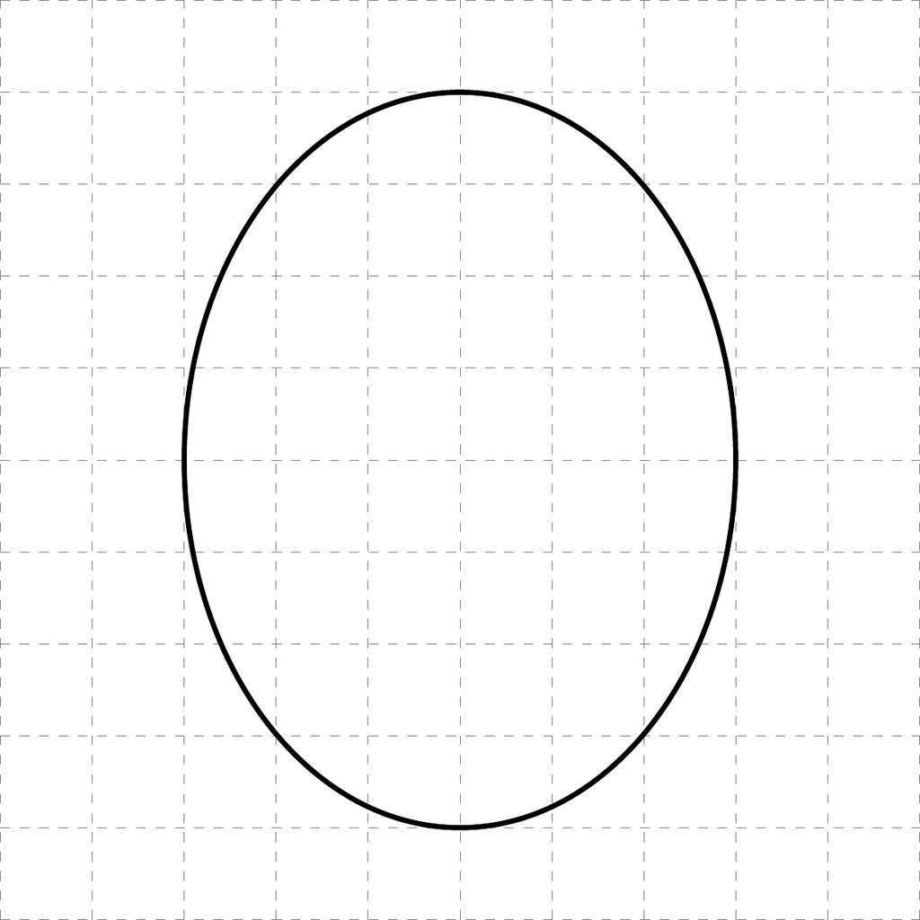

**Answer**

Based on the grid, this asteroid has a semi-major axis of 4 AU and a semi-minor axis of 3 AU. We know that the Sun is located at one of the foci points, so we can then calculate:
$$f = \sqrt{4^2 - 3^2} = 2.646$$
Remembering that this is the distance *from the center* out along the major axis, either of the two points below would be possible locations for the Sun:

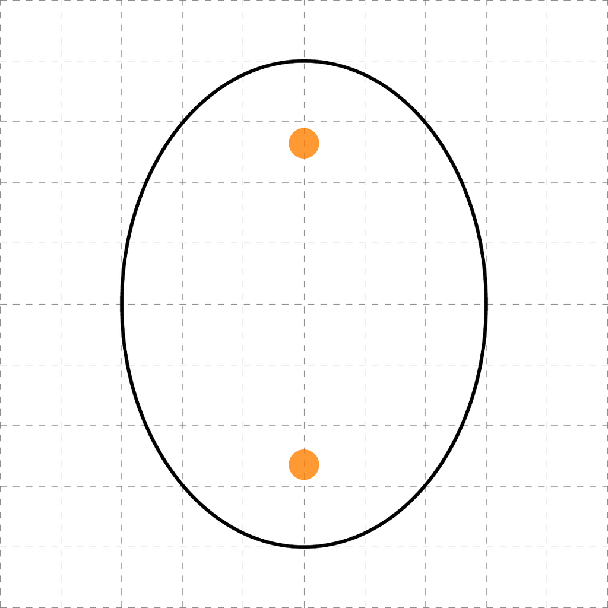

**Question 5**

Saturn has a mass of 0.029% the mass of the Sun and takes 29 years to revolve around the Sun. Approximately how far is Saturn from the Sun in AU?

**Answer**

**Question 6**

You observe the Hydrogen-$\alpha$ line (656 nm at rest) of a distant galaxy at 600 nm. What can be said about the distant galaxy?

1. It is moving towards us
2. It is moving away from us
3. It is moving sideways to us (neither towards or away)
4. It is not moving

**Answer**

You observe the Hydrogen-$\alpha$ line (656 nm at rest) of a distant galaxy at 600 nm. What can be said about the distant galaxy?

1. **It is moving towards us**
2. It is moving away from us
3. It is moving sideways to us (neither towards or away)
4. It is not moving

**Question 7**

Earth and Venus are approximately the same size. As viewed from Mercury, how would their angular sizes compare when their orbital positions were perfectly lined up?

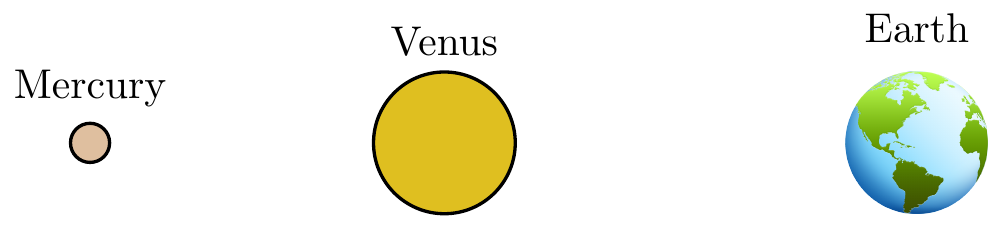

1. Earth would be larger
2. Venus would be larger
3. They would have approximately the same angular size
4. It is impossible to know without knowing the exact distances between them

**Answer**

Earth and Venus are approximately the same size. As viewed from Mercury, how would their angular sizes compare when their orbital positions were perfectly lined up?

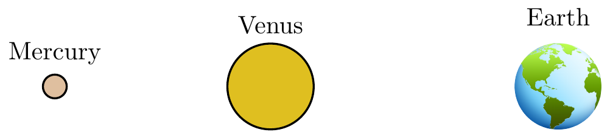

1. Earth would be larger
2. **Venus would be larger**
3. They would have approximately the same angular size
4. It is impossible to know without knowing the exact distances between them

**Question 8**

The below spectra could have been formed by which one of the following situations?

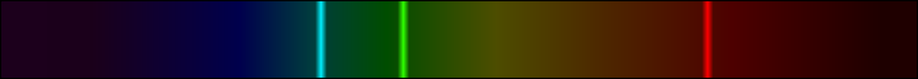

1. Energized diffuse hydrogen gas, as in a nebula
2. An O type star
3. A red-hot piece of metal
4. The glowing filament in an incandescent light bulb

**Answer**

The below spectra could have been formed by which one of the following situations?

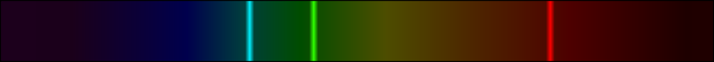

1. **Energized diffuse hydrogen gas, as in a nebula**
2. An O type star
3. A red-hot piece of metal
4. The glowing filament in an incandescent light bulb

**Question 9**

The giant star Betelgeuse has an apparent magnitude of 0.58, whereas the star Sirius has a magnitude of -1.46.

1. Will Sirius or Betelgeuse appear brighter in Earth’s night sky?
   1. Sirius
   2. Betelgeuse
   3. They will be about the same brightess
   4. Impossible to say without more information
2. Which star has the greater luminosity?
   1. Sirius
   2. Betelgeuse
   3. The have the same luminosity
   4. Impossible to say without more information

**Answer**

The giant star Betelgeuse has an apparent magnitude of 0.58, whereas the star Sirius has a magnitude of -1.46.

1. Will Sirius or Betelgeuse appear brighter in Earth’s night sky?
   1. **Sirius**
   2. Betelgeuse
   3. They will be about the same brightess
   4. Impossible to say without more information
2. Which star has the greater luminosity?
   1. Sirius
   2. Betelgeuse
   3. The have the same luminosity
   4. **Impossible to say without more information**

**Question 10**

In June, I measure the position of star A and star B relative to background stars. When I do the same measurement the following December (6 months later, or half an orbit around the Sun), I find that star A appears 10 arcseconds from its original location, whereas star B appears 3 arcseconds from its original position. What can be concluded?

1. Star A is closer to Earth than star B
2. Star B is closer to Earth than star A
3. Star A is traveling through space faster than star B
4. Star B is much more luminous than star A

**Answer**

In June, I measure the position of star A and star B relative to background stars. When I do the same measurement the following December (6 months later, or half an orbit around the Sun), I find that star A appears 10 arcseconds from its original location, whereas star B appears 3 arcseconds from its original position. What can be concluded?

1. **Star A is closer to Earth than star B**
2. Star B is closer to Earth than star A
3. Star A is traveling through space faster than star B
4. Star B is much more luminous than star A

**Question 11**

Use the below Hertzsprung-Russell Diagram to answer the following questions.

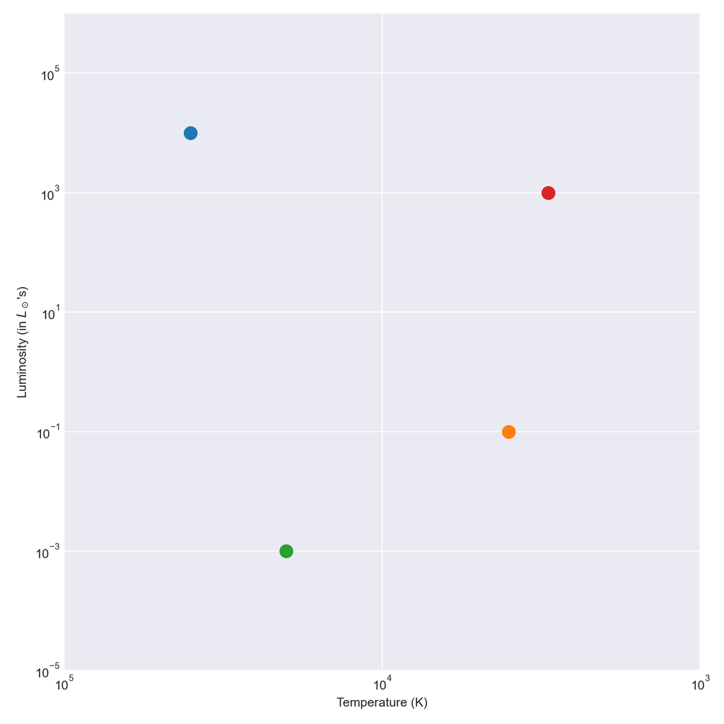

1. Put a star next to all the main sequence stars
2. Circle the largest star
3. Draw a triangle around the star most likely to be a white dwarf
4. Draw a skull near the main sequence star with the shortest lifetime.

**Answers**

Use the below Hertzsprung-Russell Diagram to answer the following questions.

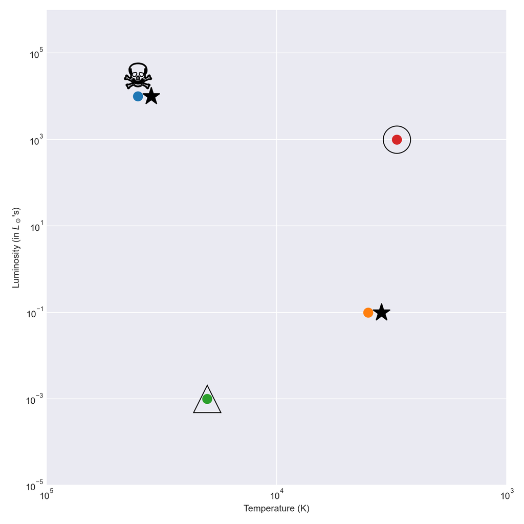

1. Put a star next to all the main sequence stars
2. Circle the largest star
3. Draw a triangle around the star most likely to be a white dwarf
4. Draw a skull near the main sequence star with the shortest lifetime.

**Question 12**

Briefly describe how you can compare the relative ages of star clusters, and why this technique works.

**Answer**

All stars in a star cluster are approximately the same age, and thus formed around the same time. Hotter, more massive stars though have much shorter lifetimes, as they fuse through their Hydrogen supply very quickly. As such, we can imagine the main sequence almost as a candle wick, that burns down from the upper left to the lower right as time goes on. As the “candle” burns down and stars run out of Hydrogen, they drift toward the upper right, becoming giants. As such, we can determine the relative age of a star cluster by observing how far “down” the main sequence the “candle” has burned, moving stars off the main sequence and up to the upper right. The further down the main sequence things have progressed, the older the cluster. The oldest clusters should show signs of stars in the white dwarf portion of the HR diagram.